# 2.6 - Noah's Notes - Our First Predictive Model

This document details the development of our first artificial intelligence software project, focused on predicting mask requirements. The process is structured in the following steps:

1. Importing necessary libraries.
2. Data preparation and preprocessing.
3. Definition of the model components.
4. Implementation of the training loop.
5. Visualization and analysis of results.
6. Application of the model to make predictions.

### Step 1: Importing Necessary Libraries

To start, we will import the essential Python libraries for this project. Two main libraries have been selected for their suitability and simplicity.

- `numpy`: Fundamental library for numerical computing in Python. It will be used for manipulating data arrays and performing mathematical operations.
- `matplotlib`: Library for creating static, interactive, and animated visualizations in Python. It will be used to visualize the data and the model results.

```python
# Code Block 1: Importing our libraries

import numpy as np
import matplotlib.pyplot as plt

# A quick print to confirm everything is loaded and ready. Good practice!
print("Toolkit ready. NumPy and Matplotlib are loaded and ready.")
```

```
Matplotlib is building the font cache; this may take a moment.
```

```
Toolkit ready. NumPy and Matplotlib are loaded and ready.
```

### Step 2: Data Preparation and Preprocessing

Our model needs data to learn. While Martha and Ethan work with the hospital's real database, I am creating a "synthetic" dataset. It will act as if it were real, mimicking the relationship between patients (x) and required masks (y), but with a random touch to make it appear realistic.

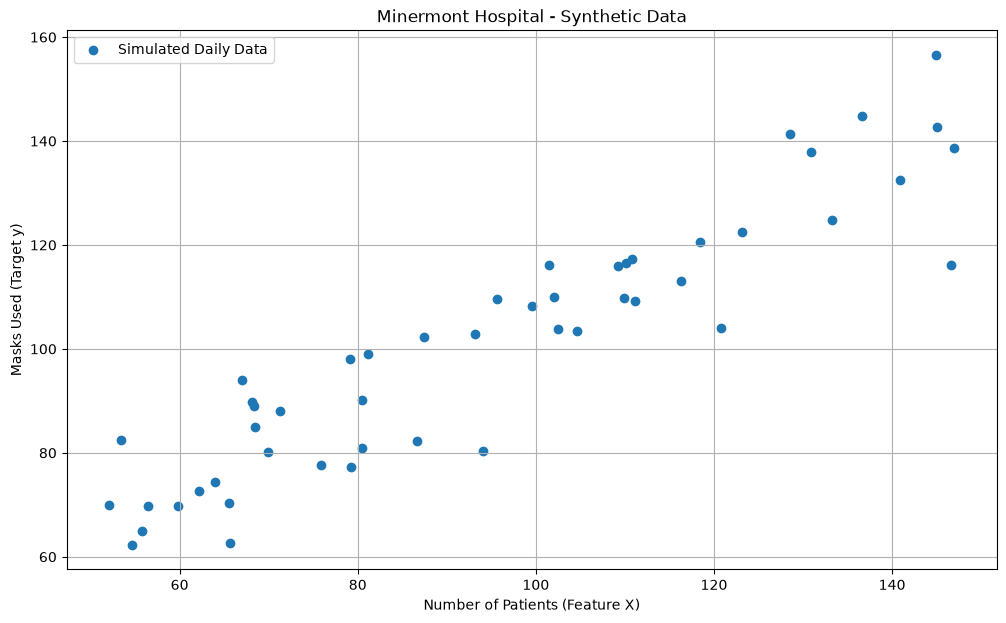

```python
# Code Block 2: Creating a Synthetic and Realistic Dataset

# Setting a 'random seed'. This is crucial in machine learning software
# to ensure that 'random' numbers are the same each time the code runs,
# making results reproducible.
np.random.seed(42)

# Simulate data for 50 days.
m = 50  # 'm' is the standard variable name for the number of training examples.

# X = Number of Patients. Generate 50 random values between 50 and 150.
# The shape (m, 1) creates a column vector.
X = 50 + 100 * np.random.rand(m, 1)

# y = Number of Masks Used.
# Define a relationship: y = 25 (base) + 0.8 * X + some random noise.
# This simulates a real-world scenario where the relationship isn't perfectly linear.
y = 25 + 0.8 * X + np.random.randn(m, 1) * 10

# First step with any dataset is to visualize it.
# Plot to confirm it looks as expected.
plt.figure(figsize=(12, 7))
plt.scatter(X, y, label='Simulated Daily Data')
plt.title("Minermont Hospital - Synthetic Data")
plt.xlabel("Number of Patients (Feature X)")
plt.ylabel("Masks Used (Target y)")
plt.grid(True)
plt.legend()
plt.show()
```

### Step 3: Defining the Model Components

Martha gave us the blueprint, now let's define the core pieces in our code:

- The Hypothesis ($h(x)$): This is our prediction function. For linear regression, it's just the equation of a line. We'll call it `prediction()`. $$prediction(x) = w * x + b$$ $w$ (weight) and $b$ (bias) are the parameters our model will learn. These are the "controls" we adjust.
- The Cost Function ($J(w, b)$): This tells us how "wrong" our model's predictions are. The lower, the better. We'll use Mean Squared Error (MSE), a fairly standard choice. $$cost = averageOf( (prediction - actualvalue)^2 )$$
- Gradient Descent: This is the actual learning process. It automatically adjusts $w$ and $b$ to minimize the cost. It finds the "slope" of the cost function and takes steps downhill.

### Step 4: Implementing the Training Loop

This is the heart of our program. We will initialize our parameters and then run a loop that repeatedly refines them using Gradient Descent.

**Since this is a very small dataset with only 50 entries and to keep the code simple, we will use batch gradient descent, using all 50 entries in each iteration.**

```python
# Code Block 3: Building and Training the Model (with Early Stopping)

# --- 1. Parameter Initialization ---
# Provide the model a starting point. Initialize w and b to 0.
# A simple, neutral starting position.
w = 0.0
b = 0.0

# --- 2. Hyperparameter Setup ---
# These are adjustments for the learning algorithm, not learned from the data.
# We need to set them manually.
learning_rate = 0.0001     # How large each update step is. Smaller values are safer.
num_iterations = 10000      # Maximum number of iterations.
alpha = 0.001              # Minimum change in cost to continue (early stopping threshold).

# --- 3. Training Loop ---
# We'll store the cost at each step to observe the model's learning progress.
cost_log = []

print("Starting training sequence...")
for i in range(num_iterations):
    # a) Make predictions for ALL data points with current w and b.
    y_pred = w * X + b

    # b) Calculate the cost (MSE) for these predictions.
    # This tells us how well we're doing in this iteration.
    cost = np.mean((y_pred - y)**2)
    cost_log.append(cost)

    # --- Early Stopping Condition ---
    # If the cost hasn't changed much compared to the previous step,
    # we've reached a flat region and aren't learning much more.
    if i > 0 and abs(cost_log[-2] - cost_log[-1]) < alpha:
        print(f"Early stopping at iteration {i} due to minimal change in cost.")
        break

    # c) Compute gradients. Core of the learning process.
    # These formulas come from the derivative of the cost function.
    # They indicate the slope of our cost "hill" for w and b.
    dw = (1/m) * np.sum((y_pred - y) * X)  # Gradient for weight
    db = (1/m) * np.sum(y_pred - y)        # Gradient for bias

    # d) Update parameters.
    # Move w and b in the *opposite* direction of the gradient.
    # This is the "downhill" step.
    w = w - learning_rate * dw
    b = b - learning_rate * db

    # Simple logging to monitor progress in real time.
    # Print error evolution every 100 iterations
    # Start printing the first iteration since error at 0 is not meaningful with random w and b
    if ((i-1) % 100) == 0:
        print(f"Iteration {i}: Cost = {cost:.6f}")

# Print number of iterations and final error
print("\n--- Training Complete ---")
print(f"Number of iterations: {i}")
print(f"Final error: {cost:.6f}")
print(f"Final learned weight (w): {w:.4f}")
print(f"Final learned bias (b): {b:.4f}")
```

```
Starting training sequence...
Iteration 1: Cost = 149.453144
Iteration 101: Cost = 143.590561
Iteration 201: Cost = 143.488009
Iteration 301: Cost = 143.385628
Iteration 401: Cost = 143.283419
Iteration 501: Cost = 143.181381
Iteration 601: Cost = 143.079514
Iteration 701: Cost = 142.977817
Iteration 801: Cost = 142.876291
Iteration 901: Cost = 142.774934
Iteration 1001: Cost = 142.673747
Iteration 1101: Cost = 142.572729
Iteration 1201: Cost = 142.471881
Iteration 1301: Cost = 142.371201
Iteration 1401: Cost = 142.270689
Iteration 1501: Cost = 142.170346
Iteration 1601: Cost = 142.070171
Early stopping at iteration 1657 due to minimal change in cost.

--- Training Complete ---
Number of iterations: 1657
Final error: 142.014146
Final learned weight (w): 1.0363
Final learned bias (b): 0.3832
```

### Step 5: Visualization and Analysis of Results

Okay, we’ve built the engine. But is it really working? In machine learning, we need to visualize.

First, let's plot the learning curve. This shows how the cost decreases over time. If this plot doesn't go down, something went wrong.

Then, we'll plot the final line our model learned over the original data. This is the ultimate visual check to see how well it fits.

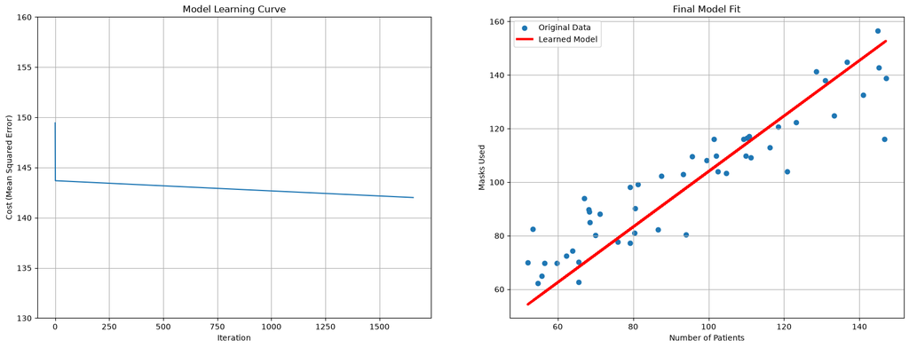

```python
# Code Block 4: Visualizing Model Performance

# Create a figure with two side-by-side plots for a nice report.
fig, (ax1, ax2) = plt.subplots(1, 2, figsize=(20, 7))

# Remove the first cost log value since w and b were 0 initially
# and this cost is not representative
cost_log.pop(0)

# --- Plot 1: Learning Curve ---
ax1.plot(cost_log)
ax1.set_ylim(130, 160)  # Set y-axis based on previous error values
ax1.set_title("Model Learning Curve")
ax1.set_xlabel("Iteration")
ax1.set_ylabel("Cost (Mean Squared Error)")
ax1.grid(True)

# --- Plot 2: Final Regression Line ---
# First, add the original data points to the plot
ax2.scatter(X, y, label='Original Data')
# Then, add the line representing the learned model
# Generate y values for the line using our final w and b
ax2.plot(X, w * X + b, color='red', linewidth=3, label='Learned Model')
ax2.set_title("Final Model Fit")
ax2.set_xlabel("Number of Patients")
ax2.set_ylabel("Masks Used")
ax2.grid(True)
ax2.legend()

plt.show()
```

### Step 6: Applying the Model to Make Predictions

Alright, the goal was to build something useful! Now that our model is trained, let's use it to predict mask requirements for new scenarios.

This is the reward: taking our trained `w` and `b` and plugging them into our line equation.

```python
# Code Block 5: Making a Prediction

# Suppose we want to know how many masks to budget if we expect 100 patients tomorrow.
patients_tomorrow = 100

# Use our trained final w and b to compute the prediction.
predicted_masks = w * patients_tomorrow + b

print("\n--- Making a New Prediction ---")
print(f"For a day with {patients_tomorrow} patients...")
print(f"Our model predicts we will need approximately {int(predicted_masks)} masks.")

# Let's try another for a quieter day.
patients_quiet_day = 65
predicted_masks_quiet = w * patients_quiet_day + b
print(f"\nFor a day with {patients_quiet_day} patients...")
print(f"Our model predicts we will need approximately {int(predicted_masks_quiet)} masks.")
```

```
--- Making a New Prediction ---
For a day with 100 patients...
Our model predicts we will need approximately 104 masks.

For a day with 65 patients...
Our model predicts we will need approximately 67 masks.
```

# Conclusion and Next Steps

We have successfully implemented an initial predictive model based on linear regression to estimate mask requirements. This fundamental approach was developed from scratch.